# Logistic Regression

## 目录

1.Logistic回归是什么?

2.为什么要用Logistic回归?

3.如何估计参数?

4.模型形式为什么长这样?

## Logistic回归是什么?

Logidtic回归是在线性回归模型的基础上做一个变换,用来分类的模型.

模型形式: \[P(Y=1|X) = h_\theta(X) = \frac{1}{1 + e^{-\theta^T X}}\]

\(P(Y=1|X)\)表示给定\(X\),相应的\(Y=1\)的概率.

## 为什么要用Logistic回归?

为什么要做这样一个怪异的变换?

- 线性回归易受极端值的影响
- 把线性回归的值归一化到\([0, 1]\),用来表示概率

## 线性回归分类 VS Logistic回归分类

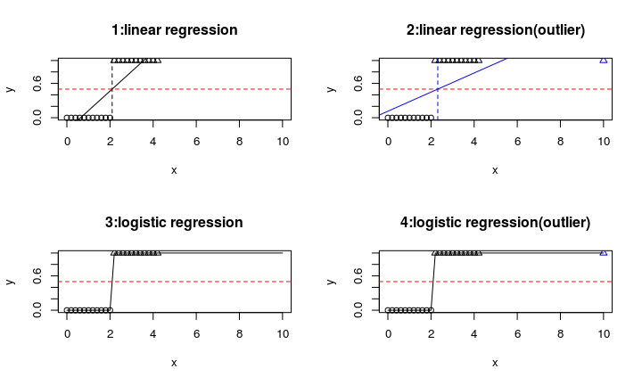

以0.5为分割界限,图2中加入一个极值点后线性回归分错一个样本;

而图4中Logistic回归对极值点并不敏感.

## 参数估计: 最小二乘?

\[ J = \sum (y_i - h_{\theta}(x_i))^2\] \[ \frac{\partial J }{\partial\theta} = \sum 2(y_i-h_\theta(x_i))* \frac{\partial h_\theta(x_i)}{\partial \theta}\]

\(h_\theta(x) = \frac{1}{1+e^{-\theta^Tx}}\)形式怪异,计算复杂.

最小二乘在这里并不易于求解.

## 参数估计: 最大似然!

思想:寻找参数使得已知样本出现的概率最大.

单个样本的似然函数: \[L_i(\theta) = h_\theta(x_i)^{y_i} * (1-h_\theta(x_i))^{1-y_i}\]

即\(P(Y=y_i|X=x_i)\),给定\(x_i\)出现\(y_i\)的概率.

所有样本的似然函数: \[L(\theta) =\prod_{i=1}^{n} h_\theta(x_i)^{y_i} * (1-h_\theta(x_i))^{1-y_i}\]

这里假设各样本相互独立.

## 参数估计: 最大似然!

对似然函数取对数,便得到最终的目标函数: \[\ln{L(\theta)} = \sum_{i=1}^{n} y_i \ln h_\theta(x_i)+ (1-y_i) \ln (1-h_\theta(x_i))\]

运用梯度下降法找到\(\theta\)使得\(\ln L(\theta)\)最大. 梯度为: \[\frac{\partial \ln L(\theta)}{\theta_j} = \sum_{i=1}^{n} (h_\theta(x_i) - y_i)x_{ij} \]

其中\(x_{ij}\)表示第\(i\)个样本第\(j\)个变量的值.

## \(h_\theta(X)\)为什么长这样?

能够把连续数值归一化到\([0, 1]\)的函数有很多:

\[|sin(x)|, \frac{x-\min(x)}{\max(x)-\min(x)}, \int_{-\inf}^{x}\frac{1}{\sqrt{2\pi}}e^{-\frac{t^2}{2}} dt, …\]

为什么偏偏是\(\frac{1}{1+e^{-x}}\)?

这不是随便挑的,也不是一个巧合,背后水很深…

## 指数分布族

线性回归里的响应变量服从正态分布;  
logistic回归的响应变量服从伯努利分布;

事实上,**正态分布**和**伯努利分布**都是**指数分布族**的一员.

指数分布族的面貌是: \[p(y, \eta) = b(y) exp(\eta^T T(y) - a(\eta))\]

\(\eta\): 自然参数(natural parameter);  
\(T(y)\): 充分统计量(sufficient statistic);  
\(a(\eta)\): 归一化参数,保证分布从负无穷到正无穷的积分为1;

选取合适的\(\eta, a, T(y), b(y)\),上式可以变换成正态分布,指数分布,泊松分布,伽马分布,伯努利分布…

## 广义线性回归

根据响应变量的分布形式,选择指数分布族里的某种特定分布作回归,便是广义线性回归.

广义线性回归的假设:

- 随机变量\(y\)的分布取决于非随机变量\(x\)和参数\(\theta\),且\(y|x,\theta ~ expFamily(\eta)\);
- 模型形式是\(h(x) = E[T(y)|x]\),通常有\(T(y)=y\);
- \(\eta=\theta^Tx\),即\(\eta\)可是\(\theta\)的线性变换;

## 广义线性回归之Logistic回归

对于伯努利分布\(y~B(\phi)\): \[\begin{align} p(y, \phi) &= \phi^y(1-\phi)^{1-y} \\ &= exp(y\ln\phi + (1-y)ln(1-\phi)) \\ &= exp(y*\ln \frac{\phi}{1-\phi} + \ln(1-\phi)) \end{align}\]

对照指数分布族的形式有: \[b(y)=1; T(y)=y; \eta=\ln \frac{\phi}{1-\phi};\]

即:\(\phi = \frac{1}{1+e^{-\eta}}\). 又广义线性回归假设3\(\eta=\theta^Tx\),于是有: \[P(y=1) = \phi = \frac{1}{1+e^{-\eta}} = \frac{1}{1+e^{-\theta^Tx}}\]

## 参考

[1]机器学习的动机与应用[Vedio](http://v.163.com/movie/2008/1/E/D/M6SGF6VB4_M6SGHKAED.html)

[2]机器学习的动机与应用[Lecture](http://cs229.stanford.edu/notes/cs229-notes1.pdf)